# CBE423 Assignment 2

Kevin Park

## 1

### 1.1

PBE is a GGA functional.

### 1.2

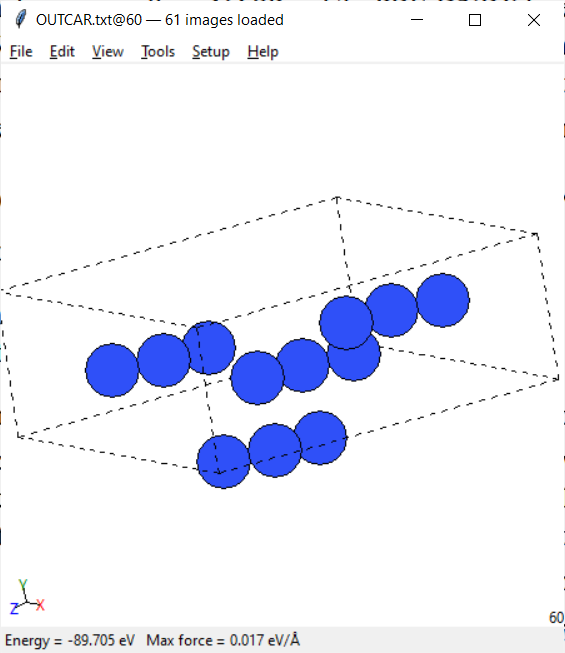

### 1.3

```python
from ase.io import read

# load data
atoms = read('./problem_1/OUTCAR.txt',index='-1')

# get cell parameters
params = atoms.get_cell_lengths_and_angles()

print(params)
```

```
[  6.25365154   3.68162549   8.65560159  90.         117.29399588
  90.        ]
```

## 2

### 2.1

a) Charge: 0, Spin Multiplicity: 2 b) Charge: 0, Spin Multiplicity: 1 c) Charge: 0, Spin Multiplicity: 1

### 2.2

a) B3LYP is a hybrid functional. b) If def2-TZVP is too computationally intractable, a lower accuracy basis set such as def2-SVP can be used instead.

### 2.4

```python
from ase.io import read

atoms = read('./problem_2/n6.xyz')
```

[output not shown]

Using `ase gui n6.xyz` and 'ase gui OUTCAR.txt`.

| Method: ORCA | 1 | 2 | 3 | 4 | 5 | 6 |
| --- | --- | --- | --- | --- | --- | --- |
| Distance from i+1 ($\dot{\text{A}}$) | 1.128 | 1.238 | 1.440 | 1.238 | 1.128 | 0 |
| Angle w.r.t neighbors ($\deg$) | N/A | 172.3 | 109.6 | 109.6 | 172.3 | N/A |

| Method: Figure 4a | 1 | 2 | 3 | 4 | 5 | 6 |
| --- | --- | --- | --- | --- | --- | --- |
| Distance from i+1 ($\dot{\text{A}}$) | 1.138 | 1.251 | 1.460 | 1.251 | 1.138 | 0 |
| Angle w.r.t neighbors ($\deg$) | N/A | 172.5 | 107 | 107 | 172.5 | N/A |

| Method: Problem 1 | 1 | 2 | 3 | 4 | 5 | 6 |
| --- | --- | --- | --- | --- | --- | --- |
| Distance from i+1 ($\dot{\text{A}}$) | 1.142 | 1.243 | 1.415 | 1.243 | 1.142 | 0 |
| Angle w.r.t neighbors ($\deg$) | N/A | 167.3 | 111.9 | 107 | 172.5 | N/A |

Overall, the results using ORCA are similar to those of Figure 4a and Problem!

### 2.5

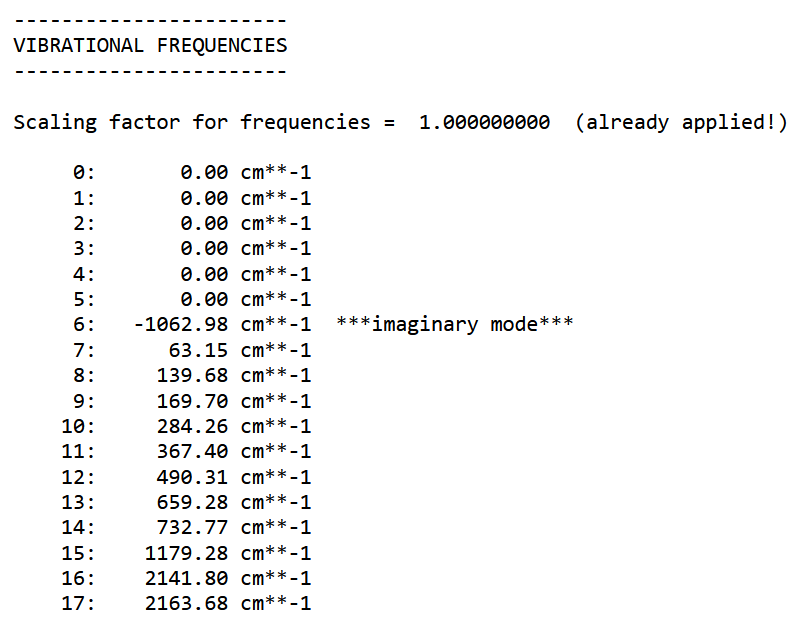

There is exactly one vibrational mode of magnitude $1062.98\text{ cm}^{-1}$. This makes intuitive sense as a transition state/saddle point should have at least one imaginary frequency from a geometric perspective (at least one negative curvature). The magnitude is also reasonable $N_6$ is likely to decay to $N_2$; a large magnitude reflects this "attraction" to decay.

### 2.6

Note to convert $Eh$ to $\frac{\text{kcal}}{\text{mol}}$, multiply by $627.509$. Also, note that Figure 4a uses the Gibbs Free Energy of $N_6$ as a baseline.

Thus, the following formula is used: $$\Delta G_{molecule}=(G_{molecule}-G_{N_6})\cdot627.509$$

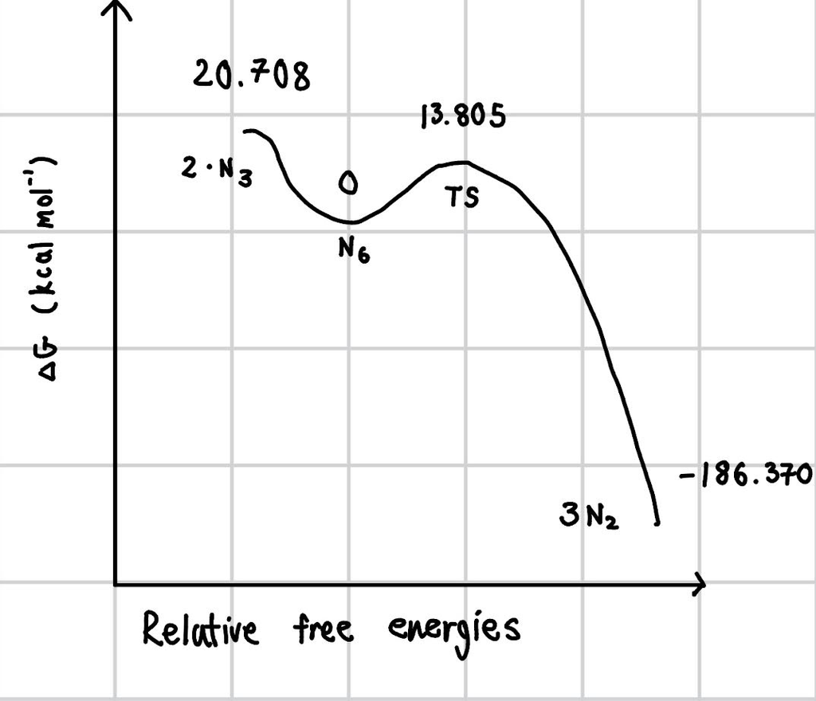